# Training and Tuning of Machine Learning Models for Alzheimer’s Disease Prediction

This notebook focuses on the training and evaluation of multiple machine learning models for Alzheimer’s disease prediction. Several classification algorithms are implemented and tuned, including Logistic Regression, tree-based models, ensemble methods, SVM, and KNN, in order to compare their predictive performance.

The models are trained under three different scenarios: without dimensionality reduction, with PCA retaining 95% of the variance, and with a 2D PCA representation mainly used for visualization. This allows analyzing the impact of dimensionality reduction on model performance and class separability.

Model performance is compared using standard evaluation metrics, and the best-performing models are saved and exported for later use in a separate notebook dedicated to making predictions on new data.

- PCA and Analysis of Variance
- Model with KNN
- Training Models
- Train Models
- Model Comparison Chart
- Confusion Matrix of the best model
- Gradient Boosting Confusion Matrix
- SMOTE Application (Balancer)
- Results
- Conclusion
- References

## Imported modules

```python
import pickle
import numpy as np
import matplotlib.pyplot as plt
from sklearn.metrics import accuracy_score, f1_score, confusion_matrix, classification_report
from sklearn.model_selection import GridSearchCV
from sklearn.decomposition import PCA
import seaborn as sns

# Models
from sklearn.linear_model import LogisticRegression
from sklearn.tree import DecisionTreeClassifier
from sklearn.ensemble import RandomForestClassifier, GradientBoostingClassifier
from xgboost import XGBClassifier
from sklearn.svm import SVC
from sklearn.neighbors import KNeighborsClassifier
from imblearn.over_sampling import SMOTE
from sklearn.model_selection import GridSearchCV
from sklearn.metrics import accuracy_score, f1_score, precision_score, recall_score, confusion_matrix
from sklearn.metrics import ConfusionMatrixDisplay

print("Imported modules")
```

```
Imported modules
```

## Loading the Transformed Dataset

```python
with open("dataset_transformado.pkl", "rb") as f:
    data = pickle.load(f)

X_train = data["X_train_prep"]
X_test = data["X_test_prep"]
y_train = data["y_train"]
y_test = data["y_test"]

print("Dataset loaded successfully.")
```

```
Dataset loaded successfully.
```

## PCA and Analysis of Variance

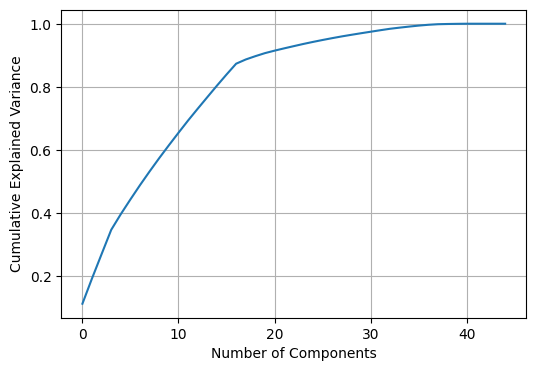

```
Components necessary for 95% variance: 27
```

```python
pca_full = PCA()
pca_full.fit(X_train)

var_acum = np.cumsum(pca_full.explained_variance_ratio_)

plt.figure(figsize=(6,4))
plt.plot(var_acum)
plt.xlabel("Number of Components")
plt.ylabel("Cumulative Explained Variance")
plt.grid(True)
plt.savefig("grafica_PCA.png", dpi=300, bbox_inches='tight')
plt.show()

# Automatic component selection to achieve 95%
n_componentes_95 = np.argmax(var_acum >= 0.95) + 1
print("Components necessary for 95% variance:", n_componentes_95)

# PCA with 2 components (for visualization)
pca2 = PCA(n_components=2)
X_train_pca2 = pca2.fit_transform(X_train)
X_test_pca2 = pca2.transform(X_test)

# PCA for 95% variance
pca95 = PCA(n_components=n_componentes_95)
X_train_pca95 = pca95.fit_transform(X_train)
X_test_pca95 = pca95.transform(X_test)
```

**Conclusion**

Principal Component Analysis (PCA) was applied to the training dataset to reduce dimensionality and assess the amount of information retained by each component. The analysis showed that 27 components are required to capture 95% of the total variance, indicating that a large portion of the information is distributed across multiple variables and that it is not possible to drastically reduce dimensionality without losing significant information.

## 2D PCA Graph

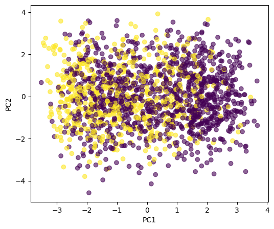

```python
plt.figure(figsize=(6, 5))
plt.scatter(X_train_pca2[:,0], X_train_pca2[:,1], c=y_train, alpha=0.6)
plt.xlabel("PC1")
plt.ylabel("PC2")
plt.savefig("grafica_PCA2D.png", dpi=300, bbox_inches='tight')
plt.show()
```

## Model with KNN

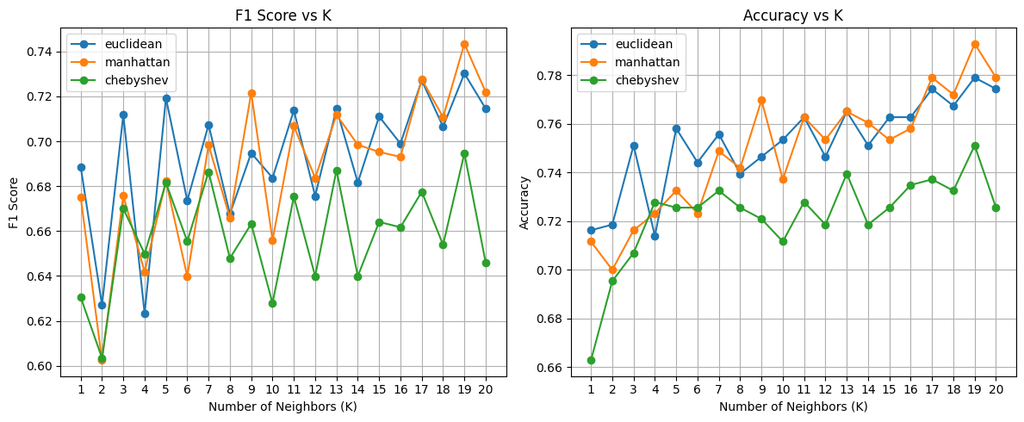

```
Mejor K para euclidean: 19 con F1-score = 0.7302
Mejor K para manhattan: 19 con F1-score = 0.7435
Mejor K para chebyshev: 19 con F1-score = 0.6946
```

```python
distancias = ["euclidean", "manhattan", "chebyshev"]
k_range = range(1, 21)

resultados_knn = {}

for dist in distancias:
    f1_scores = []
    accuracies = []

    for k in k_range:
        knn = KNeighborsClassifier(n_neighbors=k, metric=dist)
        knn.fit(X_train, y_train)
        y_pred = knn.predict(X_test)

        f1_scores.append(f1_score(y_test, y_pred, average="macro"))
        accuracies.append(accuracy_score(y_test, y_pred))

    resultados_knn[dist] = {"f1": f1_scores, "accuracy": accuracies}

# Chart results
plt.figure(figsize=(12,5))

# F1-score
plt.subplot(1,2,1)
for dist in distancias:
    plt.plot(k_range, resultados_knn[dist]["f1"], marker='o', label=dist)
plt.title("F1 Score vs K")
plt.xlabel("Number of Neighbors (K)")
plt.ylabel("F1 Score")
plt.xticks(k_range)
plt.grid(True)
plt.legend()

# Accuracy
plt.subplot(1,2,2)
for dist in distancias:
    plt.plot(k_range, resultados_knn[dist]["accuracy"], marker='o', label=dist)
plt.title("Accuracy vs K")
plt.xlabel("Number of Neighbors (K)")
plt.ylabel("Accuracy")
plt.xticks(k_range)
plt.grid(True)
plt.legend()

plt.tight_layout()
plt.savefig("grafica_KNN.png", dpi=300, bbox_inches='tight')
plt.show()

# Obtain the best K and distance according to F1-score
for dist in distancias:
    f1_scores = np.array(resultados_knn[dist]["f1"])
    best_k = k_range[np.argmax(f1_scores)]
    best_score = f1_scores.max()
    print(f"Mejor K para {dist}: {best_k} con F1-score = {best_score:.4f}")
```

**Conclusion**

The KNN model showed that the optimal number of neighbors is 19 for the three evaluated distance metrics. Among them, the Manhattan distance achieved the best performance with an F1-score of 0.7435, followed by the Euclidean distance (0.7302) and the Chebyshev distance (0.6946). This indicates that the KNN model can predict Alzheimer’s disease diagnosis with moderately good performance, and that the choice of distance metric significantly influences the effectiveness of the classifier.

## Training Models

```python
modelos = {
    "LogisticRegression": (
        LogisticRegression(max_iter=500),
        {"C": [0.1, 1, 10]}
    ),
    "DecisionTree": (
        DecisionTreeClassifier(),
        {"max_depth": [3, 5, 10, None]}
    ),
    "RandomForest": (
        RandomForestClassifier(),
        {"n_estimators": [100, 300], "max_depth": [5, 10, None]}
    ),
    "GradientBoosting": (
        GradientBoostingClassifier(),
        {"learning_rate": [0.01, 0.1, 0.3], "n_estimators": [100, 300]}
    ),
    "XGBoost": (
        XGBClassifier(eval_metric="logloss"),
        {"learning_rate": [0.01, 0.1], "n_estimators": [200, 400]}
    ),
    "SVM": (
        SVC(),
        {"C": [1, 10], "kernel": ["rbf", "linear"]}
    ),
    "KNN": (
        KNeighborsClassifier(),
        {"n_neighbors": [3, 5, 7, 19]}
    )
}
```

## Function for training models

```python
def entrenar_modelos(X_train, X_test, y_train, y_test):
    resultados = {}

    for nombre, (modelo, parametros) in modelos.items():
        print(f"\nTraining and optimizing  {nombre}...")

        grid = GridSearchCV(modelo, parametros, cv=5, scoring="f1_macro", n_jobs=-1)
        grid.fit(X_train, y_train)

        mejor_modelo = grid.best_estimator_
        y_pred = mejor_modelo.predict(X_test)

        resultados[nombre] = {
            "modelo": mejor_modelo,
            "accuracy": accuracy_score(y_test, y_pred),
            "f1": f1_score(y_test, y_pred, average="macro"),
            "precision": precision_score(y_test, y_pred, average="macro"),
            "recall": recall_score(y_test, y_pred, average="macro"),
            "matriz": confusion_matrix(y_test, y_pred),
        }

        print(f"Best Model: {mejor_modelo}")
        print("Accuracy:", resultados[nombre]["accuracy"])
        print("F1 Score:", resultados[nombre]["f1"])
        print("Precision:", resultados[nombre]["precision"])
        print("Recall:", resultados[nombre]["recall"])


    return resultados
```

## Train models without PCA

```python
print("\nTrain models without PCA...")
resultados_sinpca = entrenar_modelos(X_train, X_test, y_train, y_test)
```

```
Entrenando modelos SIN PCA...

Entrenando y optimizando LogisticRegression...
Mejor modelo: LogisticRegression(C=0.1, max_iter=500)
Accuracy: 0.8325581395348837
F1 Score: 0.8151376913707038
Precision: 0.8183243295388771
Recall: 0.812358008330178

Entrenando y optimizando DecisionTree...
Mejor modelo: DecisionTreeClassifier(max_depth=5)
Accuracy: 0.9279069767441861
F1 Score: 0.9217075161959133
Precision: 0.918865635426145
Recall: 0.9248627413858387

Entrenando y optimizando RandomForest...
Mejor modelo: RandomForestClassifier(n_estimators=300)
Accuracy: 0.9279069767441861
F1 Score: 0.919221422987656
Precision: 0.93155377295035
Recall: 0.9099536160545247

Entrenando y optimizando GradientBoosting...
Mejor modelo: GradientBoostingClassifier(learning_rate=0.3, n_estimators=300)
Accuracy: 0.9441860465116279
F1 Score: 0.938943581976524
Precision: 0.938943581976524
Recall: 0.938943581976524

Entrenando y optimizando XGBoost...
Mejor modelo: XGBClassifier(base_score=None, booster=None, callbacks=None,
              colsample_bylevel=None, colsample_bynode=None,
              colsample_bytree=None, device=None, early_stopping_rounds=None,
              enable_categorical=False, eval_metric='logloss',
              feature_types=None, feature_weights=None, gamma=None,
              grow_policy=None, importance_type=None,
              interaction_constraints=None, learning_rate=0.01, max_bin=None,
              max_cat_threshold=None, max_cat_to_onehot=None,
              max_delta_step=None, max_depth=None, max_leaves=None,
              min_child_weight=None, missing=nan, monotone_constraints=None,
              multi_strategy=None, n_estimators=200, n_jobs=None,
              num_parallel_tree=None, ...)
Accuracy: 0.9488372093023256
F1 Score: 0.9435142945854929
Precision: 0.9479548524020838
Recall: 0.9395588792124195

Entrenando y optimizando SVM...
Mejor modelo: SVC(C=1, kernel='linear')
Accuracy: 0.8209302325581396
F1 Score: 0.8049725807116646
Precision: 0.8036950146627566
Recall: 0.806347027641045

Entrenando y optimizando KNN...
Mejor modelo: KNeighborsClassifier(n_neighbors=7)
Accuracy: 0.7558139534883721
F1 Score: 0.7073407875546913
Precision: 0.7463406668448087
Recall: 0.6963508140855736
```

## Train models with 95% PCA

```python
print("\nTrain models with 95% PCA...")
resultados_pca95 = entrenar_modelos(X_train_pca95, X_test_pca95, y_train, y_test)
```

```
Entrenando modelos con PCA 95%...

Entrenando y optimizando LogisticRegression...
Mejor modelo: LogisticRegression(C=10, max_iter=500)
Accuracy: 0.8093023255813954
F1 Score: 0.7874059425043411
Precision: 0.7939655172413793
Recall: 0.7824450965543355

Entrenando y optimizando DecisionTree...
Mejor modelo: DecisionTreeClassifier(max_depth=5)
Accuracy: 0.7744186046511627
F1 Score: 0.7521083567595195
Precision: 0.7533139076643818
Recall: 0.7509939416887543

Entrenando y optimizando RandomForest...
Mejor modelo: RandomForestClassifier(max_depth=10, n_estimators=300)
Accuracy: 0.8325581395348837
F1 Score: 0.8023947509510072
Precision: 0.8427556818181818
Recall: 0.7855215827338129

Entrenando y optimizando GradientBoosting...
Mejor modelo: GradientBoostingClassifier()
Accuracy: 0.8395348837209302
F1 Score: 0.8155710955710955
Precision: 0.8388946267312836
Recall: 0.8028445664521016

Entrenando y optimizando XGBoost...
Mejor modelo: XGBClassifier(base_score=None, booster=None, callbacks=None,
              colsample_bylevel=None, colsample_bynode=None,
              colsample_bytree=None, device=None, early_stopping_rounds=None,
              enable_categorical=False, eval_metric='logloss',
              feature_types=None, feature_weights=None, gamma=None,
              grow_policy=None, importance_type=None,
              interaction_constraints=None, learning_rate=0.1, max_bin=None,
              max_cat_threshold=None, max_cat_to_onehot=None,
              max_delta_step=None, max_depth=None, max_leaves=None,
              min_child_weight=None, missing=nan, monotone_constraints=None,
              multi_strategy=None, n_estimators=400, n_jobs=None,
              num_parallel_tree=None, ...)
Accuracy: 0.8325581395348837
F1 Score: 0.80935960591133
Precision: 0.8267798013245033
Recall: 0.7989397955319955

Entrenando y optimizando SVM...
Mejor modelo: SVC(C=10, kernel='linear')
Accuracy: 0.813953488372093
F1 Score: 0.7918935269207501
Precision: 0.7999553305539011
Recall: 0.7860422188564937

Entrenando y optimizando KNN...
Mejor modelo: KNeighborsClassifier(n_neighbors=7)
Accuracy: 0.7372093023255814
F1 Score: 0.6864574662356182
Precision: 0.7197802197802198
Recall: 0.6774895872775464
```

## Training models with 2D PCA

```python
print("\nTraining models with 2D PCA...")
resultados_pca2 = entrenar_modelos(X_train_pca2, X_test_pca2, y_train, y_test)
```

```
Entrenando modelos con PCA 2D...

Entrenando y optimizando LogisticRegression...
Mejor modelo: LogisticRegression(C=1, max_iter=500)
Accuracy: 0.6534883720930232
F1 Score: 0.5768471247135281
Precision: 0.6041633935585232
Recall: 0.5784503975766755

Entrenando y optimizando DecisionTree...
Mejor modelo: DecisionTreeClassifier(max_depth=3)
Accuracy: 0.672093023255814
F1 Score: 0.578052905192392
Precision: 0.6331455399061032
Recall: 0.5838934115865203

Entrenando y optimizando RandomForest...
Mejor modelo: RandomForestClassifier()
Accuracy: 0.6581395348837209
F1 Score: 0.5921172348374857
Precision: 0.6126739926739927
Recall: 0.5909929950776222

Entrenando y optimizando GradientBoosting...
Mejor modelo: GradientBoostingClassifier()
Accuracy: 0.6651162790697674
F1 Score: 0.5575752379319214
Precision: 0.6223359973359973
Recall: 0.5695522529344945

Entrenando y optimizando XGBoost...
Mejor modelo: XGBClassifier(base_score=None, booster=None, callbacks=None,
              colsample_bylevel=None, colsample_bynode=None,
              colsample_bytree=None, device=None, early_stopping_rounds=None,
              enable_categorical=False, eval_metric='logloss',
              feature_types=None, feature_weights=None, gamma=None,
              grow_policy=None, importance_type=None,
              interaction_constraints=None, learning_rate=0.1, max_bin=None,
              max_cat_threshold=None, max_cat_to_onehot=None,
              max_delta_step=None, max_depth=None, max_leaves=None,
              min_child_weight=None, missing=nan, monotone_constraints=None,
              multi_strategy=None, n_estimators=200, n_jobs=None,
              num_parallel_tree=None, ...)
Accuracy: 0.6395348837209303
F1 Score: 0.579046428052624
Precision: 0.5910973084886129
Recall: 0.5780954184021204

Entrenando y optimizando SVM...
Mejor modelo: SVC(C=10)
Accuracy: 0.6581395348837209
F1 Score: 0.5260588883640371
Precision: 0.6109214134202494
Recall: 0.5507383566830746

Entrenando y optimizando KNN...
Mejor modelo: KNeighborsClassifier(n_neighbors=3)
Accuracy: 0.6302325581395349
F1 Score: 0.5766327535280604
Precision: 0.5835409836065574
Recall: 0.5753739113971981
```

## Model Comparison Chart

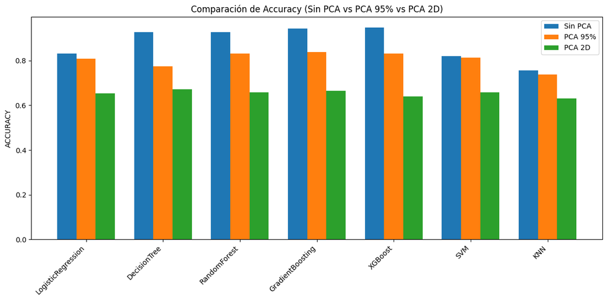

[output not shown]

```python
def grafico_comparacion(metric, titulo, resultados_sinpca, resultados_pca95, resultados_pca2):
    modelos = list(resultados_sinpca.keys())

    sinpca = [resultados_sinpca[m][metric] for m in modelos]
    pca95 = [resultados_pca95[m][metric] for m in modelos]
    pca2 = [resultados_pca2[m][metric] for m in modelos]

    x = np.arange(len(modelos))
    width = 0.25

    plt.figure(figsize=(12,6))
    plt.bar(x - width, sinpca, width, label="Sin PCA")
    plt.bar(x, pca95, width, label="PCA 95%")
    plt.bar(x + width, pca2, width, label="PCA 2D")

    plt.xticks(x, modelos, rotation=45, ha="right")
    plt.title(titulo)
    plt.ylabel(metric.upper())
    plt.legend()
    plt.tight_layout()

    nombre_archivo = titulo.replace(" ", "_") + ".png"

    plt.show()


grafico_comparacion("accuracy",
                    "Accuracy Comparison (No PCA vs. PCA 95% vs. PCA 2D)",
                    resultados_sinpca, resultados_pca95, resultados_pca2)
```

**Models with PCA 95% (95% variance retention):**

- Performance slightly decreased compared to models without PCA, but Gradient Boosting, XGBoost, and Random Forest remained the best-performing models (F1 ≈ 0.81–0.82).
- This shows that dimensionality reduction while retaining 95% of the variance allows good performance to be maintained, although slightly lower than when using all features.

**Models with PCA 2D (only two principal components for visualization):**

- Performance deteriorated significantly (F1 ≈ 0.53–0.59).
- This aligns with the observation that the first two principal components do not clearly separate the classes, making classification more difficult.

## Confusion Matrix of the best model

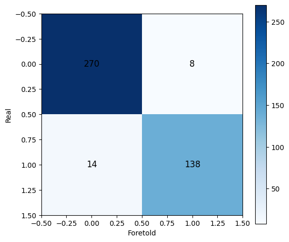

```
El mejor modelo SIN PCA es: XGBoost
```

```python
def mejor_modelo_global(resultados):
    return max(resultados, key=lambda m: resultados[m]["f1"])

mejor = mejor_modelo_global(resultados_sinpca)
matriz = resultados_sinpca[mejor]["matriz"]

plt.figure(figsize=(6,5))
plt.imshow(matriz, cmap="Blues")
plt.xlabel("Foretold")
plt.ylabel("Real")
plt.colorbar()

# Add numbers within each cell
for i in range(matriz.shape[0]):
    for j in range(matriz.shape[1]):
        plt.text(j, i, matriz[i, j],
                 ha="center", va="center", color="black", fontsize=12)

plt.tight_layout()

plt.savefig("matriz_confusion_mejor_modelo.png", dpi=300, bbox_inches="tight")
plt.show()

print("\nThe best model without PCA is: ", mejor)
```

#### **Conclusion**

- The model correctly predicts most cases: 270 patients without Alzheimer’s disease and 138 patients with Alzheimer’s disease.
- Errors include 8 false positives (patients incorrectly diagnosed with Alzheimer’s) and 14 false negatives (patients with Alzheimer’s who were not detected).

**Balanced precision and sensitivity:**

- Excellent ability to identify healthy patients (Class 0), with very few false positives.
- Good ability to detect patients with Alzheimer’s disease (Class 1), with a relatively low number of false negatives.

Overall, XGBoost demonstrates solid and well-balanced performance, minimizing both false diagnostic errors and the omission of true cases.

## Gradient Boosting Confusion Matrix

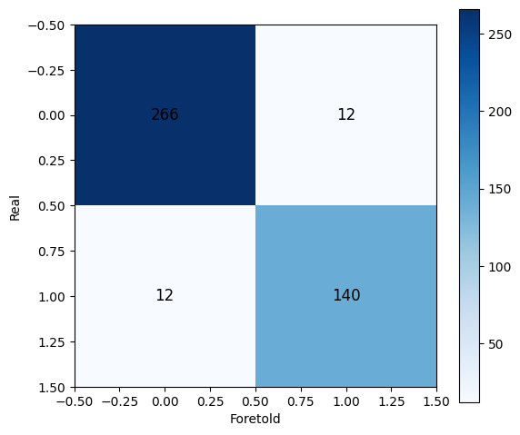

```
Matriz de confusión del modelo Gradient Boosting:
 [[266  12]
 [ 12 140]]
```

```python
matriz_gb = resultados_sinpca["GradientBoosting"]["matriz"]

plt.figure(figsize=(6,5))
plt.imshow(matriz_gb, cmap="Blues")
plt.xlabel("Foretold")
plt.ylabel("Real")
plt.colorbar()

for i in range(matriz_gb.shape[0]):
    for j in range(matriz_gb.shape[1]):
        plt.text(j, i, matriz_gb[i, j], ha="center", va="center", color="black", fontsize=12)

plt.tight_layout()
plt.savefig("matriz_confusion_GradientBoosting.png", dpi=300, bbox_inches="tight")
plt.show()

print("Confusion matrix of the Gradient Boosting model:\n", matriz_gb)
```

## SMOTE Application (Balancer)

## Application in Gradient Boosting

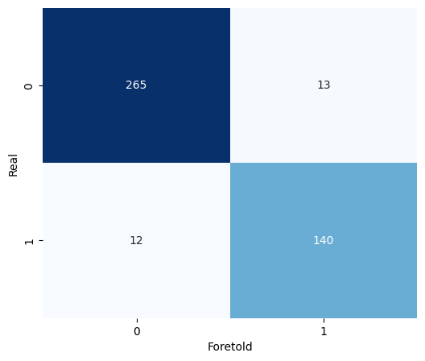

```python
# Apply SMOTE to balance classes in Gradient Boosting
smote = SMOTE(random_state=42)
X_train_bal, y_train_bal = smote.fit_resample(X_train, y_train)


gb_model = GradientBoostingClassifier()
gb_params = {"learning_rate": [0.01, 0.1, 0.3], "n_estimators": [100, 300]}

# GridSearchCV con F1-score macro
grid = GridSearchCV(gb_model, gb_params, cv=5, scoring="f1_macro", n_jobs=-1)
grid.fit(X_train_bal, y_train_bal)

# Best model and predictions
mejor_gb = grid.best_estimator_
y_pred = mejor_gb.predict(X_test)

# Metrics
accuracy = accuracy_score(y_test, y_pred)
f1 = f1_score(y_test, y_pred, average="macro")
matriz = confusion_matrix(y_test, y_pred)



# Crear heatmap de la matriz de confusión
plt.figure(figsize=(6,5))
sns.heatmap(matriz, annot=True, fmt='d', cmap='Blues', cbar=False)
plt.xlabel("Foretold")
plt.ylabel("Real")
plt.savefig("matriz_confusion_GB_SMOTE.png", dpi=300, bbox_inches="tight")

plt.show()
```

**Conclusion**

## Application in XGBoost

```
Mejor modelo XGBoost: XGBClassifier(base_score=None, booster=None, callbacks=None,
              colsample_bylevel=None, colsample_bynode=None,
              colsample_bytree=None, device=None, early_stopping_rounds=None,
              enable_categorical=False, eval_metric='logloss',
              feature_types=None, feature_weights=None, gamma=None,
              grow_policy=None, importance_type=None,
              interaction_constraints=None, learning_rate=0.1, max_bin=None,
              max_cat_threshold=None, max_cat_to_onehot=None,
              max_delta_step=None, max_depth=None, max_leaves=None,
              min_child_weight=None, missing=nan, monotone_constraints=None,
              multi_strategy=None, n_estimators=400, n_jobs=None,
              num_parallel_tree=None, ...)
Accuracy: 0.9441860465116279
F1-score macro: 0.938943581976524
```

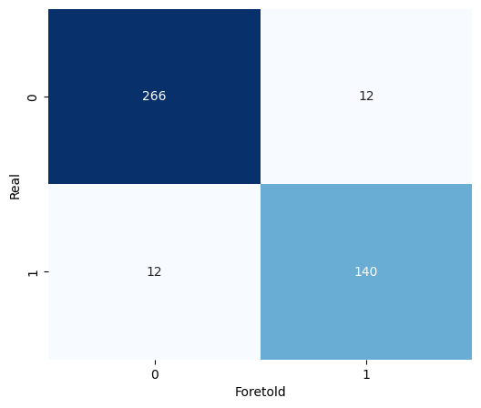

```python
# Apply SMOTE
smote = SMOTE(random_state=42)
X_train_bal, y_train_bal = smote.fit_resample(X_train, y_train)

# Define XGBoost model
xgb_model = XGBClassifier(
    eval_metric="logloss",
    use_label_encoder=False,
    random_state=42
)

# Recommended hyperparameters for XGBoost
xgb_params = {
    "learning_rate": [0.01, 0.1],
    "n_estimators": [200, 400]
}

# GridSearchCV con F1-score macro
grid = GridSearchCV(
    xgb_model,
    xgb_params,
    cv=5,
    scoring="f1_macro",
    n_jobs=-1
)

grid.fit(X_train_bal, y_train_bal)

# Best model and predictions
mejor_xgb = grid.best_estimator_
y_pred = mejor_xgb.predict(X_test)

# Metrics
accuracy = accuracy_score(y_test, y_pred)
f1 = f1_score(y_test, y_pred, average="macro")
matriz = confusion_matrix(y_test, y_pred)

# Print Metrics
print("Mejor modelo XGBoost:", mejor_xgb)
print("Accuracy:", accuracy)
print("F1-score macro:", f1)

# Heatmap of confusion matrix
plt.figure(figsize=(6,5))
sns.heatmap(matriz, annot=True, fmt='d', cmap='Blues', cbar=False)
plt.xlabel("Foretold")
plt.ylabel("Real")
plt.savefig("matriz_confusion_XGB_SMOTE.png", dpi=300, bbox_inches="tight")
plt.show()
```

**Conclusion**

## Export Models

```python
modelo_final = resultados_sinpca[mejor]["modelo"]

# Final Model without PCA
modelo_final = resultados_sinpca[mejor]["modelo"]

with open("modelo_XGBoost.pkl", "wb") as f:
    pickle.dump(modelo_final, f)

print("Model successfully exported as model_XGBoost.pkl")
```

```
Modelo exportado correctamente como modelo_XGBoost.pkl
```

```python
modelo_gb = resultados_sinpca["GradientBoosting"]["modelo"]

# Save file .pkl
with open("modelo_GradientBoosting.pkl", "wb") as f:
    pickle.dump(modelo_gb, f)

print("Gradient Boosting model successfully exported as model_GradientBoosting.pkl")
```

```
Modelo Gradient Boosting exportado correctamente como modelo_GradientBoosting.pkl
```

## Download model

```python
files.download("modelo_GradientBoosting.pkl")
files.download("modelo_XGBoost.pkl")
```

## Results

A dimensionality reduction analysis was performed using PCA, finding that 27 components are required to retain 95% of the variance, while the 2D projection showed that the classes overlap, indicating low separability. For the KNN model, the optimal number of neighbors was 19, and the Manhattan distance metric proved to be the most effective (F1 = 0.7435), followed by Euclidean and Chebyshev.

SMOTE was also applied; although it balanced the classes during training, in this case it did not improve the overall model performance, and the metrics even decreased slightly. This indicates that XGBoost already handled class imbalance well in this dataset, making the application of SMOTE unnecessary for improving prediction performance.

## Conclusion

In conclusion, XGBoost proved to be the most effective model for predicting Alzheimer’s disease in this dataset, achieving high accuracy and F1-score even without applying class balancing. Dimensionality reduction using PCA with 95% variance retention preserved a substantial portion of the useful information, while the 2D projection showed low class separability. KNN was sensitive to the choice of distance metric, with Manhattan performing best. Overall, the results indicate that tree-based models are the most suitable for this task.

## References

Esri. (s.f.). Cómo funciona XGBoost (3.3). ArcGIS Pro. https://pro.arcgis.com/es/pro-app/3.3/tool-reference/geoai/how-xgboost-works.htm

Elastic. (s.f.). ¿Qué es kNN? https://www.elastic.co/es/what-is/knn

DataScientest. (2025, 29 de agosto). Métricas en Machine Learning.https://datascientest.com/es/metricas-en-machine-learning